# Linear Mixed Effect Models

Nick Freeland, Bernice Green, Gary Marmon

2022-11-30

# Overview

Until more recently the only way to handle the type of data mixed-effects model does was through repeated measures ANOVAs. Mixed-effects models are much more versatile in handling variability within and across groups and can handle missing data, providing much better results than the ANOVAs. (Brown 2021)

- Mixed-effects models more versatile with missing data and generally better predictions

# Applications

The main application for mixed-effect models is in psychology due to the nature of their data and repeated observations across trial participants. However, the applications can extend into almost any field where the variability across a group/person is desired in the analysis. One such example is the use of mixed-effects models on published health data sets to explore the link between smoking and depression in which it was found “Smoking status is robustly associated with depression (or depressive symptomatology) at 1 ½ to 2 times the risk of nonsmoking across a variety of study designs, depression measurements, and participant populations” (Luger, Suls, and Vander Weg 2014).

- Mixed effects models: regression with variability across groups

# Assumptions

The complex nature of mixed-effects models call into question the robustness of these models and brings more focus to the model assumptions. “Mixed-effects models involve complex fitting procedures and make several assumptions, in particular about the distribution of residual and random effects. Violations of these assumptions are common in real datasets, yet it is not always clear how much these violations matter to accurate and unbiased estimation.” (Schielzeth et al. 2020). The study found mixed-effects models to be very robust to violations of these assumptions, finding the estimates were unbiased and missing random effect predictors had little effect on the fixed effect estimates but had some effects on the estimates of random effects.

- Mixed-effects models offer good prediction even if assumptions on distribution are violated

# Predicting coach preformace:

Our basic model:
$$epa = plays
+ (1+plays|coach)$$

- Parentheses indicate variable slopes and intercepts
- Other variables for consideration: pass_pct, yards_gained, no_huddle_snap, shotgun_snaps, home_adv

# The Data:

epa per play by coach:

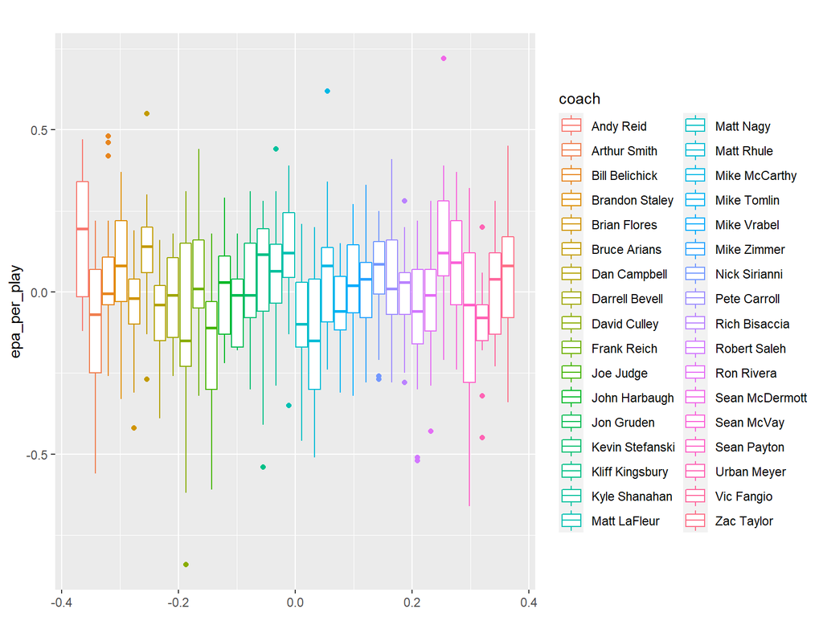

# Team Epa Performance:

[figure not shown]

# Plays:

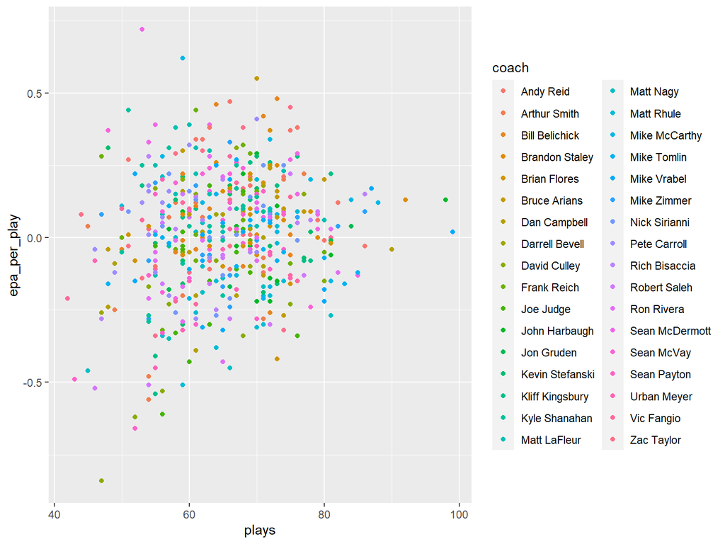

# Pass Pct:

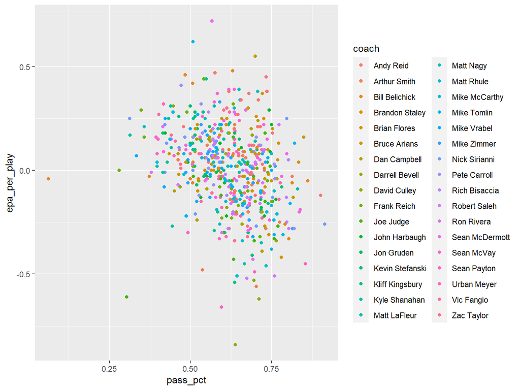

# Yards Gained:

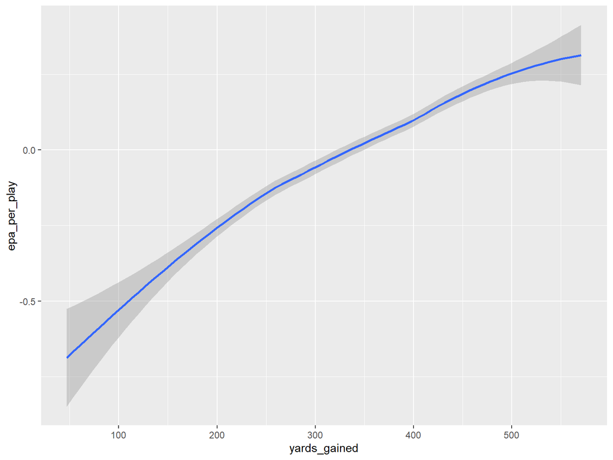

# Shotgun Snaps:

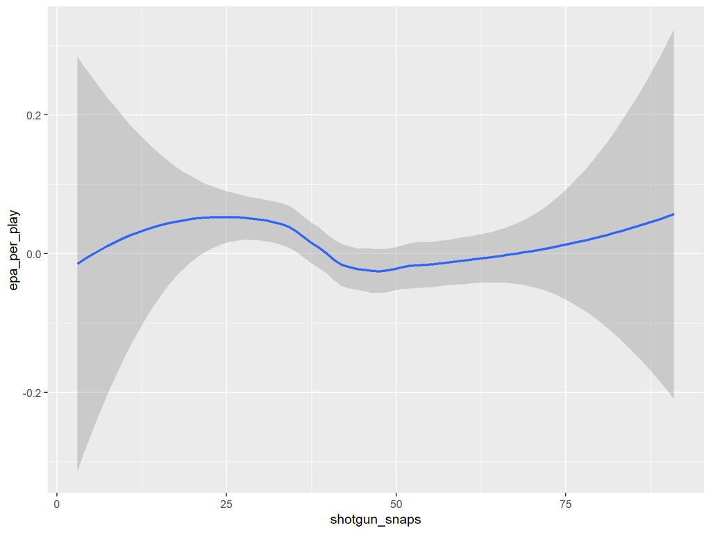

# No Huddle:

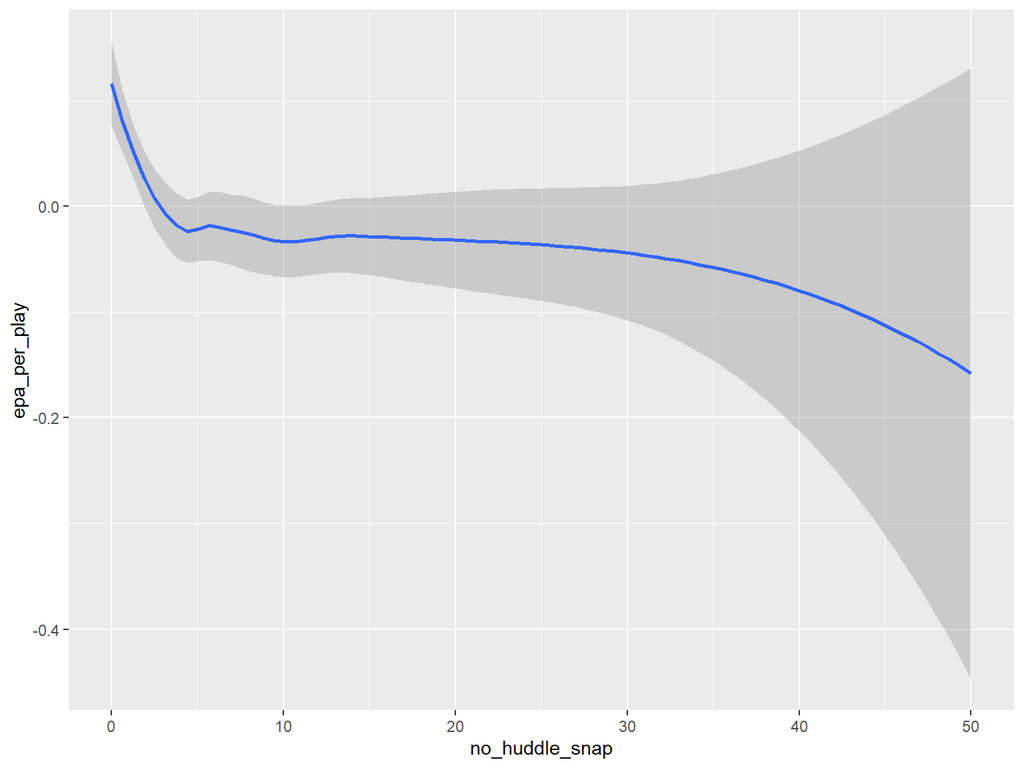

Brown, Violet A. 2021. “An Introduction to Linear Mixed-Effects Modeling in r.” *Advances in Methods and Practices in Psychological Science* 4 (1): 2515245920960351.

Luger, Tana M, Jerry Suls, and Mark W Vander Weg. 2014. “How Robust Is the Association Between Smoking and Depression in Adults? A Meta-Analysis Using Linear Mixed-Effects Models.” *Addictive Behaviors* 39 (10): 1418–29.